# Homework 3

2025-09-30

```r
# reading libraries
library(colorfindr)
library(dplyr)
```

```r
library(ggplot2)

# reading in the data
data <- read.csv("homework3_data.csv")
```

```r
summary(data$sales)
```

```
##    Min. 1st Qu.  Median    Mean 3rd Qu.    Max.
##   25.83   30.86   33.76   33.66   35.57   44.30
```

```r
# summary stats
summary(data$design)
```

```
##    Min. 1st Qu.  Median    Mean 3rd Qu.    Max.
##   0.000   0.000   0.000   0.495   1.000   1.000
```

# Color selection

```r
colors_selection_data <- get_colors("~/Desktop/get_colors_amazon.png")
cols <- make_palette(colors_selection_data[1:100, ])
```

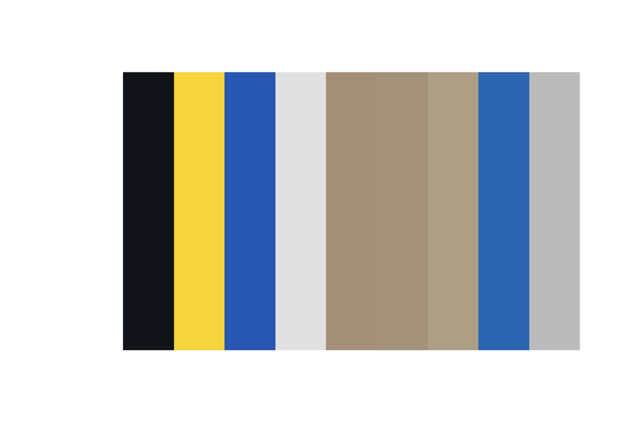

```r
data <- data %>% mutate(design_label = factor(design, levels = c(0,1),
                                              labels = c("Old Design", "New Design")))
custom_colors <- c("#F9D94C","#252F3D")

brand_map <- c("Old Design" = custom_colors[1],
               "New Design" = custom_colors[2])
```

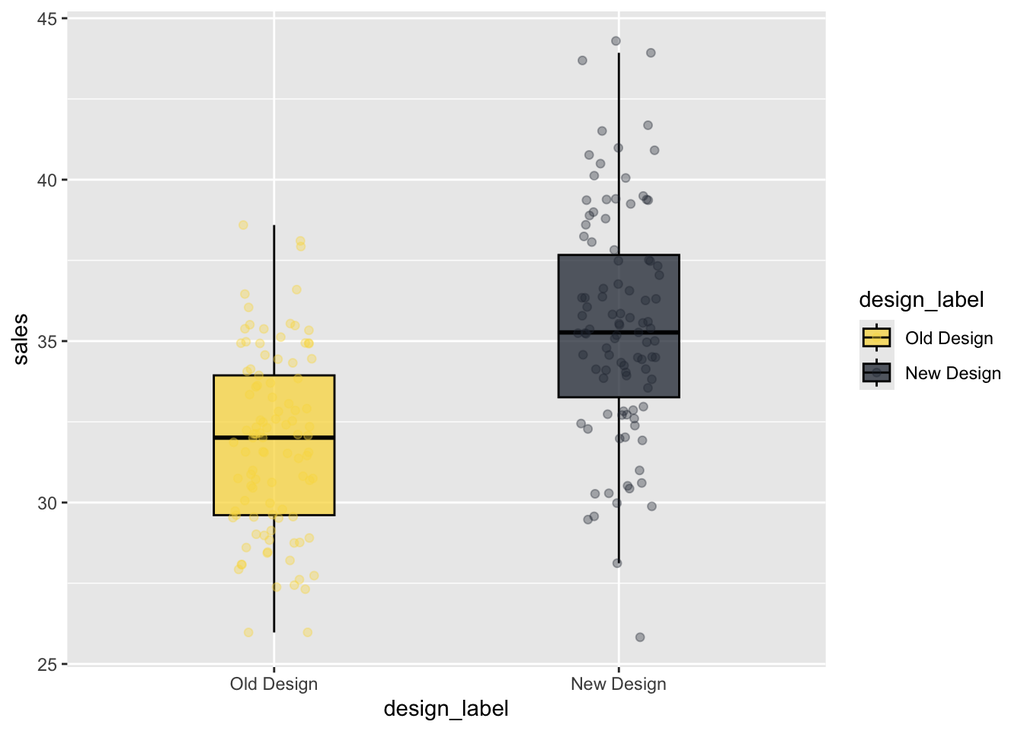

```r
ggplot(data, aes(x = design_label, y = sales, fill = design_label)) +
  geom_boxplot(width = 0.35, alpha = 0.75, outlier.shape = NA, color = "black") +
  geom_jitter(aes(color = design_label), width = 0.12, alpha = 0.35, size = 1.6) +
  scale_fill_manual(values = brand_map) +
  scale_color_manual(values = brand_map)
```

```r
  labs(title = "Sales by Design", x = NULL, y = "Sale Amount (USD") +
  theme_minimal(base_size = 14) +
  theme(legend.position = "none")
```

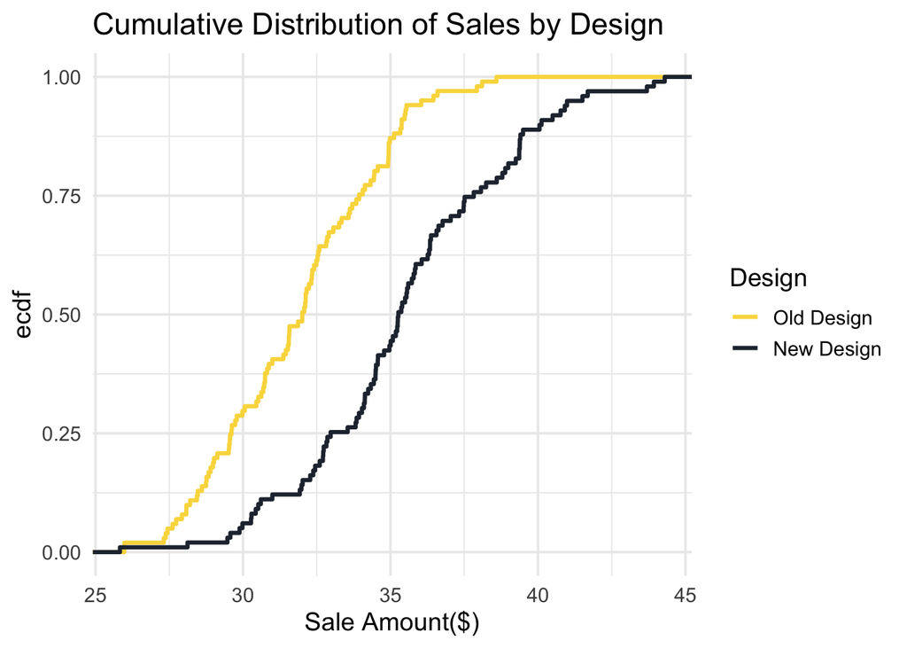

```r
ggplot(data, aes(x = sales, color = design_label)) +
  stat_ecdf(size = 1.1) +
  scale_color_manual(values = brand_map) +
  labs(title = "Cumulative Distribution of Sales by Design",
      x = "Sale Amount($)", Y = "F(x)= P(Sales <= x)", color = "Design") +
  theme_minimal(base_size = 14)
```

# Estimated Sales

```r
data %>%
  group_by(design_label) %>%
  summarise(mean_sales = mean(sales), .grops= "drop")
```

```
## # A tibble: 2 × 3
##   design_label mean_sales .grops
##   <fct>             <dbl> <chr>
## 1 Old Design         31.8 drop
## 2 New Design         35.5 drop
```

# Does it mean the $1.80 threhold?

Yes. Since $3.66 > $1.80, the redesign clears the company’s requirement. This observed gain nearly doubles that threshold. This reinforces the fact that the redesign had a meaningful positive impact on customer spending.

# Statistical Evidence

```r
t.test(sales ~ design_label, data = data, var.equal = TRUE)
```

```
##
##  Two Sample t-test
##
## data:  sales by design_label
## t = -8.1747, df = 198, p-value = 3.489e-14
## alternative hypothesis: true difference in means between group Old Design and group New Design is not equal to 0
## 95 percent confidence interval:
##  -4.549008 -2.780801
## sample estimates:
## mean in group Old Design mean in group New Design
##                 31.84819                 35.51309
```

```r
data %>%
  group_by(design_label) %>%
  summarise(mean_nps = mean(nps), .groups = "drop")
```

```
## # A tibble: 2 × 2
##   design_label mean_nps
##   <fct>           <dbl>
## 1 Old Design       4.60
## 2 New Design       5.62
```

Since the mean NPS, went up from 4.60 to 5.6, we can conclude that it strengthens the case.

# Final Recommendation

Based on the analysis, I recommend that the company full commits to the full website redesign. The Average customer sales increased from about $31.85 under the Old Design to about $35.51 under the New Design, indicating an uplift of $3.66 per customer. Since the company required at least an $1.80 increase, this effect nearly doubles that threshold. These results and evidence indicate that the redesign would meaningfully improve sales performance.

# Graphical Evidence 1: Boxplot with Jitter

The boxplot comparison between Old and New Designs show a clear upward shift in sales under the New Design. The median sales value is higher, and the spread of customer sales has shifted upward overall. The jittered points also reinforce that individual customers are more likely to have higher sales amount under the New Design. This also supports the conclusion that the redesign has a positive effect on customer spending.

# Graphical Evidence 2: ECDF

# Summary statistics

# Statistical Evidence: Two-Sample t-test

By performing a two-sample t-test comparing sales across the 2 designs, it is confirmed that the difference in means is statistically significant. The test produced a t-statistic of -8.17 and a p-value of 3.49 x 10_-14, far below the standard 0.05 significance threshold. The 95% confidence interval for the difference ranged from -4.55 to -2.78, indicating that the true sales improvement is very unlikely to be due to random chance. this test provides strong statistical confirmation that the redesign leads to higher customer sales.

# Alternative Statement

An alternative position would be to not commit to the redesign. This could be justified if the observed improvement in sales was influenced by external factors rather than the redesign itself. These external factors could be promotions or seasonal effects. Also, if the Net Promoter Scores(NPS) were to decline under the New Design, executives might worry about long-term customer loyalty, even if short-term sales increased.

# Conclusion

Taking all evidence into account, the redesign improves average customer sales by about $3.66, more than meeting the company’s required threshold Both graphical and statistical evidence support this conclusion and therefore the redesign should be pursued.